# C15

Hong Che

February 26, 2019

package analyze drug data eg(Glucocorticoids) ASM cells RNAseq: cell line (drug) alignment focus on CRISPLD2 #importing different data in ensgene: from ensembl db

```r
counts <- read.csv("data/airway_scaledcounts.csv", stringsAsFactors = FALSE)
metadata <- read.csv("data/airway_metadata.csv", stringsAsFactors = FALSE)
dim(counts)
```

```
## [1] 38694     9
```

```r
head(counts)
```

```
##           ensgene SRR1039508 SRR1039509 SRR1039512 SRR1039513 SRR1039516
## 1 ENSG00000000003        723        486        904        445       1170
## 2 ENSG00000000005          0          0          0          0          0
## 3 ENSG00000000419        467        523        616        371        582
## 4 ENSG00000000457        347        258        364        237        318
## 5 ENSG00000000460         96         81         73         66        118
## 6 ENSG00000000938          0          0          1          0          2
##   SRR1039517 SRR1039520 SRR1039521
## 1       1097        806        604
## 2          0          0          0
## 3        781        417        509
## 4        447        330        324
## 5         94        102         74
## 6          0          0          0
```

```r
head(metadata)
```

```
##           id     dex celltype     geo_id
## 1 SRR1039508 control   N61311 GSM1275862
## 2 SRR1039509 treated   N61311 GSM1275863
## 3 SRR1039512 control  N052611 GSM1275866
## 4 SRR1039513 treated  N052611 GSM1275867
## 5 SRR1039516 control  N080611 GSM1275870
## 6 SRR1039517 treated  N080611 GSM1275871
```

check matching columns

```r
#ck files
colnames(counts)
```

```
## [1] "ensgene"    "SRR1039508" "SRR1039509" "SRR1039512" "SRR1039513"
## [6] "SRR1039516" "SRR1039517" "SRR1039520" "SRR1039521"
```

```r
metadata$id
```

```
## [1] "SRR1039508" "SRR1039509" "SRR1039512" "SRR1039513" "SRR1039516"
## [6] "SRR1039517" "SRR1039520" "SRR1039521"
```

```r
#print (colnames(counts))
all(colnames(counts)[-1] == metadata$id)
```

```
## [1] TRUE
```

# find the column of the control and their mean

# Find which columns in **counts** correspond to the control conditions(ieg no drugs!). Then we calculate the mean

```r
control <- metadata[metadata[,"dex"] == "control",]
control.mean <- rowSums(counts[, control$id])/ncol(counts[,control$id]) # why 4 count of 4 treated/ctrl
names(control.mean) <- counts$ensgene
```

# only access control 2 columns

table ID(column)/ control/ Drug/ Control/ Drug for inds we only want control/ control

# dont run FIX same method as above

Now do same thing for drug treated samples (ieg treated columns)

```r
treated <- metadata[metadata[,"dex"]=="treated",]
treated.mean <- rowSums( counts[ ,treated$id] )/ncol(counts[,treated$id])
names(treated.mean) <- counts$ensgene
```

Combine the mean count values for control and treated into a new data.frame called meancounts!

```r
meancounts <- data.frame(control.mean, treated.mean)
head(meancounts)
```

```
##                 control.mean treated.mean
## ENSG00000000003       900.75       658.00
## ENSG00000000005         0.00         0.00
## ENSG00000000419       520.50       546.00
## ENSG00000000457       339.75       316.50
## ENSG00000000460        97.25        78.75
## ENSG00000000938         0.75         0.00
```

```r
colSums(meancounts)
```

```
## control.mean treated.mean
##     23005324     22196524
```

Now we can plot the drug treated vs non-drug control count values

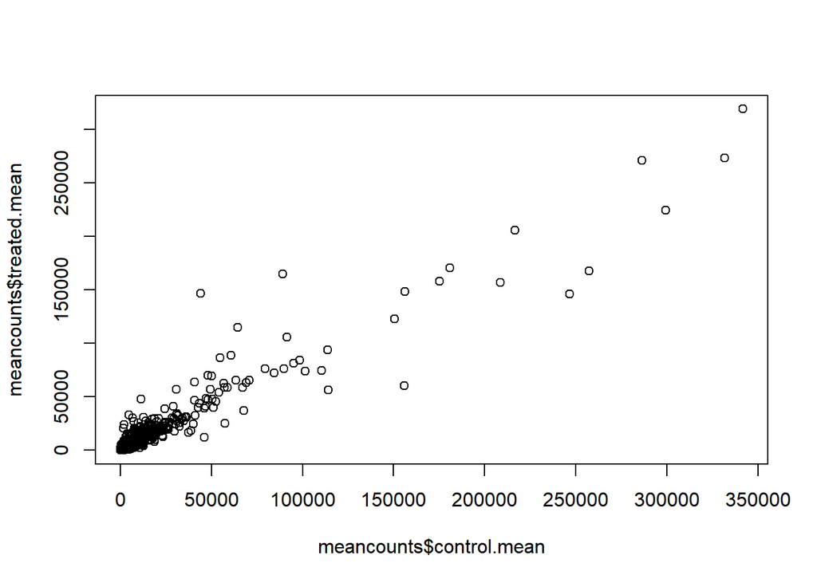

```r
plot(meancounts$control.mean, meancounts$treated.mean)
```

We can find candidate differentially expressed genes by looking for genes with a large change between control and dex-treated samples. We usually look at the log2 of the fold change, because this has better mathematical properties.

Here we calculate log2foldchange, add it to our meancounts data.frame and inspect the results either with the head() or the View() function for example.

```r
meancounts$log2fc <- log2(meancounts[,"treated.mean"]/meancounts[,"control.mean"])
head(meancounts)
```

```
##                 control.mean treated.mean      log2fc
## ENSG00000000003       900.75       658.00 -0.45303916
## ENSG00000000005         0.00         0.00         NaN
## ENSG00000000419       520.50       546.00  0.06900279
## ENSG00000000457       339.75       316.50 -0.10226805
## ENSG00000000460        97.25        78.75 -0.30441833
## ENSG00000000938         0.75         0.00        -Inf
```

```r
zero.vals <- which (meancounts[,1:2] == 0, arr.ind = TRUE)
to.rm <- unique(zero.vals[,1] )
mycounts <- meancounts[-to.rm,]
head(mycounts)
```

```
##                 control.mean treated.mean      log2fc
## ENSG00000000003       900.75       658.00 -0.45303916
## ENSG00000000419       520.50       546.00  0.06900279
## ENSG00000000457       339.75       316.50 -0.10226805
## ENSG00000000460        97.25        78.75 -0.30441833
## ENSG00000000971      5219.00      6687.50  0.35769358
## ENSG00000001036      2327.00      1785.75 -0.38194109
```

```r
#toy eg for which
toy <- c(1,2,0,4,0)
which(toy == 0)
```

```
## [1] 3 5
```

```r
toy <- meancounts[1:6,]
toy[,1:2]
```

```
##                 control.mean treated.mean
## ENSG00000000003       900.75       658.00
## ENSG00000000005         0.00         0.00
## ENSG00000000419       520.50       546.00
## ENSG00000000457       339.75       316.50
## ENSG00000000460        97.25        78.75
## ENSG00000000938         0.75         0.00
```

```r
which(toy[,1:2 ] == 0, arr.ind = TRUE) # more useful to have arr.ind
```

```
##                 row col
## ENSG00000000005   2   1
## ENSG00000000005   2   2
## ENSG00000000938   6   2
```

```r
unique(which(toy[,1:2 ] == 0, arr.ind = TRUE)[,1])
```

```
## [1] 2 6
```

remove the zero entry genes from meancounts to prooduce **mycounts**

```r
# zero.vals <- which (meancounts[,1:2] == 0, arr.ind= TRUE)
# to.rm <- unique (zero.vals[,1])
# mycounts <- meancounts[-to.rm]
# head(mycounts)
meancounts$log2fc <- log2(meancounts[,"treated.mean"]/meancounts[,"control.mean"])
head(meancounts)
```

```
##                 control.mean treated.mean      log2fc
## ENSG00000000003       900.75       658.00 -0.45303916
## ENSG00000000005         0.00         0.00         NaN
## ENSG00000000419       520.50       546.00  0.06900279
## ENSG00000000457       339.75       316.50 -0.10226805
## ENSG00000000460        97.25        78.75 -0.30441833
## ENSG00000000938         0.75         0.00        -Inf
```

```r
zero.vals <- which(meancounts[,1:2]==0, arr.ind=TRUE)

to.rm <- unique(zero.vals[,1])
mycounts <- meancounts[-to.rm,]
head(mycounts)
```

```
##                 control.mean treated.mean      log2fc
## ENSG00000000003       900.75       658.00 -0.45303916
## ENSG00000000419       520.50       546.00  0.06900279
## ENSG00000000457       339.75       316.50 -0.10226805
## ENSG00000000460        97.25        78.75 -0.30441833
## ENSG00000000971      5219.00      6687.50  0.35769358
## ENSG00000001036      2327.00      1785.75 -0.38194109
```

```r
up.ind <- mycounts$log2fc > 2
down.ind <- mycounts$log2fc < (-2)
sum(up.ind)
```

```
## [1] 250
```

```r
head(mycounts[up.ind, ])
```

```
##                 control.mean treated.mean   log2fc
## ENSG00000004799       270.50      1429.25 2.401558
## ENSG00000006788         2.75        19.75 2.844349
## ENSG00000008438         0.50         2.75 2.459432
## ENSG00000011677         0.50         2.25 2.169925
## ENSG00000015413         0.50         3.00 2.584963
## ENSG00000015592         0.50         2.25 2.169925
```

# adding annotation

parse genome ENSG00000003 to known stuff in database

merge() x is result y is annotation data by, by.x, by.y x = C/T/FC columns and y is ENSEMBL

```r
anno <- read.csv("data/annotables_grch38.csv")
head(anno)
```

```
##           ensgene entrez   symbol chr     start       end strand
## 1 ENSG00000000003   7105   TSPAN6   X 100627109 100639991     -1
## 2 ENSG00000000005  64102     TNMD   X 100584802 100599885      1
## 3 ENSG00000000419   8813     DPM1  20  50934867  50958555     -1
## 4 ENSG00000000457  57147    SCYL3   1 169849631 169894267     -1
## 5 ENSG00000000460  55732 C1orf112   1 169662007 169854080      1
## 6 ENSG00000000938   2268      FGR   1  27612064  27635277     -1
##          biotype
## 1 protein_coding
## 2 protein_coding
## 3 protein_coding
## 4 protein_coding
## 5 protein_coding
## 6 protein_coding
##                                                                                                  description
## 1                                                          tetraspanin 6 [Source:HGNC Symbol;Acc:HGNC:11858]
## 2                                                            tenomodulin [Source:HGNC Symbol;Acc:HGNC:17757]
## 3 dolichyl-phosphate mannosyltransferase polypeptide 1, catalytic subunit [Source:HGNC Symbol;Acc:HGNC:3005]
## 4                                               SCY1-like, kinase-like 3 [Source:HGNC Symbol;Acc:HGNC:19285]
## 5                                    chromosome 1 open reading frame 112 [Source:HGNC Symbol;Acc:HGNC:25565]
## 6                          FGR proto-oncogene, Src family tyrosine kinase [Source:HGNC Symbol;Acc:HGNC:3697]
```

```r
mycounts.annotated <- merge(x=mycounts, y = anno, by.x="row.names", by.y = "ensgene")
head(mycounts.annotated)
```

```
##         Row.names control.mean treated.mean      log2fc entrez   symbol
## 1 ENSG00000000003       900.75       658.00 -0.45303916   7105   TSPAN6
## 2 ENSG00000000419       520.50       546.00  0.06900279   8813     DPM1
## 3 ENSG00000000457       339.75       316.50 -0.10226805  57147    SCYL3
## 4 ENSG00000000460        97.25        78.75 -0.30441833  55732 C1orf112
## 5 ENSG00000000971      5219.00      6687.50  0.35769358   3075      CFH
## 6 ENSG00000001036      2327.00      1785.75 -0.38194109   2519    FUCA2
##   chr     start       end strand        biotype
## 1   X 100627109 100639991     -1 protein_coding
## 2  20  50934867  50958555     -1 protein_coding
## 3   1 169849631 169894267     -1 protein_coding
## 4   1 169662007 169854080      1 protein_coding
## 5   1 196651878 196747504      1 protein_coding
## 6   6 143494811 143511690     -1 protein_coding
##                                                                                                  description
## 1                                                          tetraspanin 6 [Source:HGNC Symbol;Acc:HGNC:11858]
## 2 dolichyl-phosphate mannosyltransferase polypeptide 1, catalytic subunit [Source:HGNC Symbol;Acc:HGNC:3005]
## 3                                               SCY1-like, kinase-like 3 [Source:HGNC Symbol;Acc:HGNC:19285]
## 4                                    chromosome 1 open reading frame 112 [Source:HGNC Symbol;Acc:HGNC:25565]
## 5                                                     complement factor H [Source:HGNC Symbol;Acc:HGNC:4883]
## 6                                          fucosidase, alpha-L- 2, plasma [Source:HGNC Symbol;Acc:HGNC:4008]
```

# DESeq2 analysis

puts p value for above steps now we do this analysis properly with p-values!

```r
library(DESeq2) # dependencies
```

# set up object having all these in it

DESeqDataSet = 1 countMatrix 2 metadataFile 3 designExperiment tell it focus on drug SH = dds

```r
dds <- DESeqDataSetFromMatrix(countData = counts,
                              colData = metadata,
                              design = ~dex,
                              tidy=TRUE)
dds
```

```
## class: DESeqDataSet
## dim: 38694 8
## metadata(1): version
## assays(1): counts
## rownames(38694): ENSG00000000003 ENSG00000000005 ...
##   ENSG00000283120 ENSG00000283123
## rowData names(0):
## colnames(8): SRR1039508 SRR1039509 ... SRR1039520 SRR1039521
## colData names(4): id dex celltype geo_id
```

```r
dds <- DESeq((dds))
res <- results(dds)
head(res)
```

```
## log2 fold change (MLE): dex treated vs control
## Wald test p-value: dex treated vs control
## DataFrame with 6 rows and 6 columns
##                          baseMean     log2FoldChange             lfcSE
##                         <numeric>          <numeric>         <numeric>
## ENSG00000000003  747.194195359907  -0.35070296228142 0.168242083227575
## ENSG00000000005                 0                 NA                NA
## ENSG00000000419  520.134160051965  0.206107283859668 0.101041504451637
## ENSG00000000457  322.664843927049 0.0245270113332215 0.145133863749003
## ENSG00000000460   87.682625164828 -0.147142630021569  0.25699544204927
## ENSG00000000938 0.319166568913118  -1.73228897394308  3.49360097648095
##                               stat             pvalue              padj
##                          <numeric>          <numeric>         <numeric>
## ENSG00000000003  -2.08451390730246 0.0371134465299012 0.163017154203989
## ENSG00000000005                 NA                 NA                NA
## ENSG00000000419   2.03982793979795 0.0413674659663301 0.175936611081177
## ENSG00000000457  0.168995785681273  0.865799956262632 0.961682459669788
## ENSG00000000460  -0.57254957071713  0.566949713034425 0.815805192488045
## ENSG00000000938 -0.495846258804286  0.620002884826012                NA
```

padjusted, pvalue,

```r
summary(res)
```

```
##
## out of 25258 with nonzero total read count
## adjusted p-value < 0.1
## LFC > 0 (up)       : 1564, 6.2%
## LFC < 0 (down)     : 1188, 4.7%
## outliers [1]       : 142, 0.56%
## low counts [2]     : 9971, 39%
## (mean count < 10)
## [1] see 'cooksCutoff' argument of ?results
## [2] see 'independentFiltering' argument of ?results
```

# volcano plot = significantly regulated genes vs fold change

```r
res05 <- results(dds , alpha = 0.05)
summary(res05)
```

```
##
## out of 25258 with nonzero total read count
## adjusted p-value < 0.05
## LFC > 0 (up)       : 1237, 4.9%
## LFC < 0 (down)     : 933, 3.7%
## outliers [1]       : 142, 0.56%
## low counts [2]     : 9033, 36%
## (mean count < 6)
## [1] see 'cooksCutoff' argument of ?results
## [2] see 'independentFiltering' argument of ?results
```

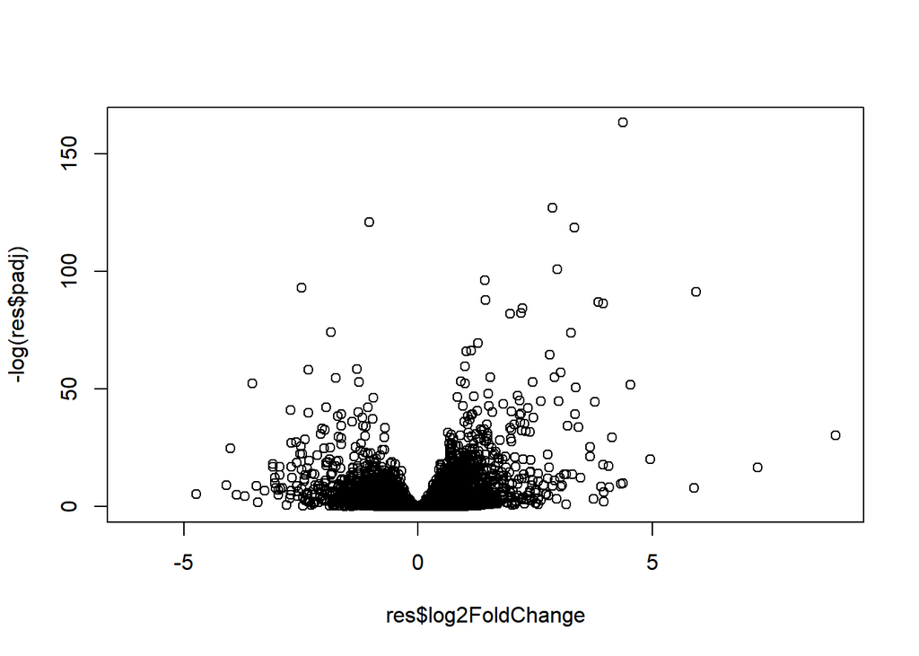

```r
plot(res$log2FoldChange, -log(res$padj))
```

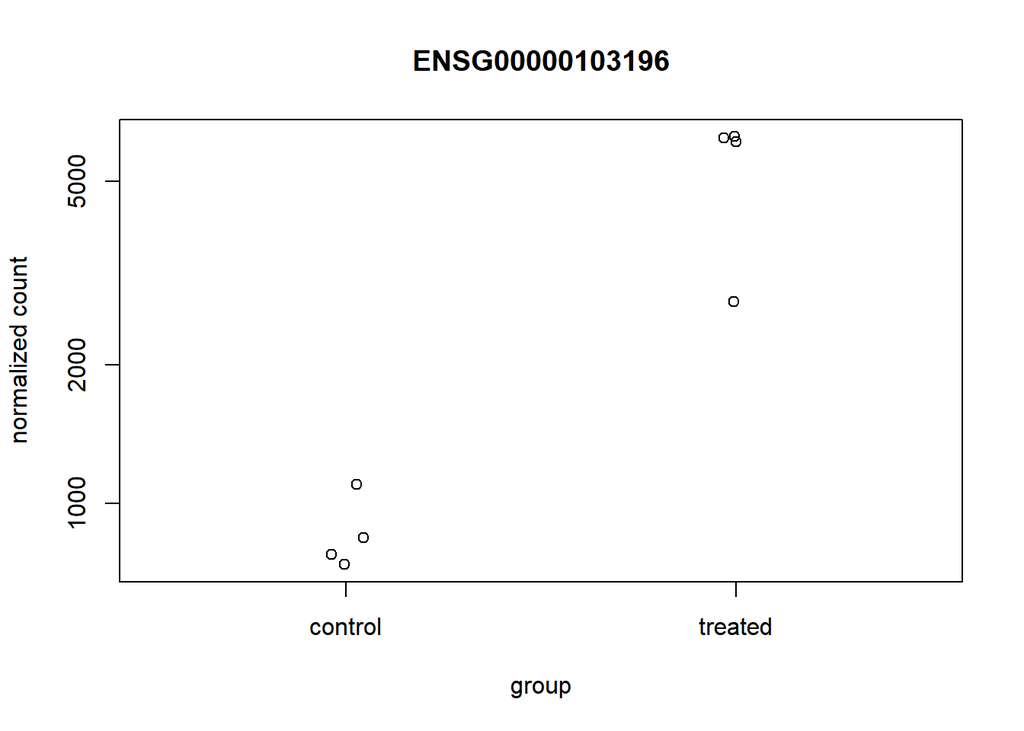

```r
plotCounts(dds, gene="ENSG00000103196", intgroup="dex")
```

```r
d <- plotCounts(dds, gene="ENSG00000103196", intgroup="dex", returnData=TRUE)
head(d)
```

```
##                count     dex
## SRR1039508  774.5002 control
## SRR1039509 6258.7915 treated
## SRR1039512 1100.2741 control
## SRR1039513 6093.0324 treated
## SRR1039516  736.9483 control
## SRR1039517 2742.1908 treated
```

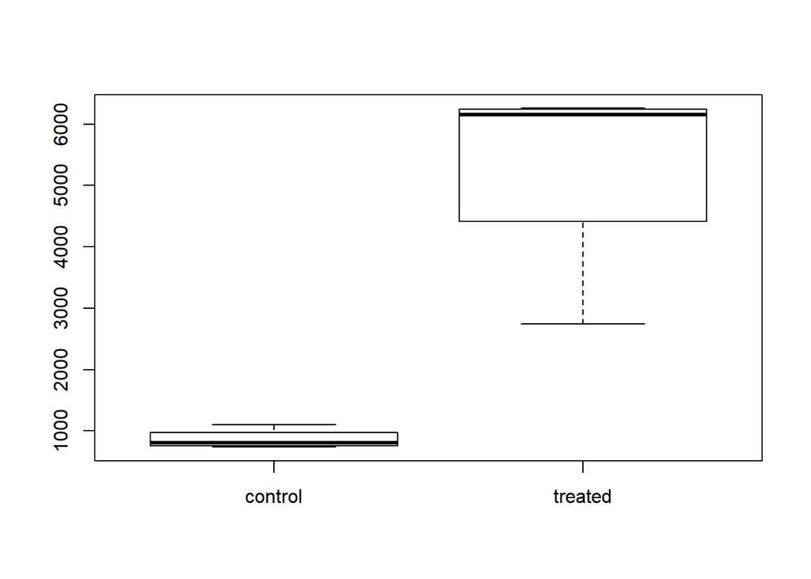

```r
boxplot(count ~ dex , data=d)
```

another fold chain

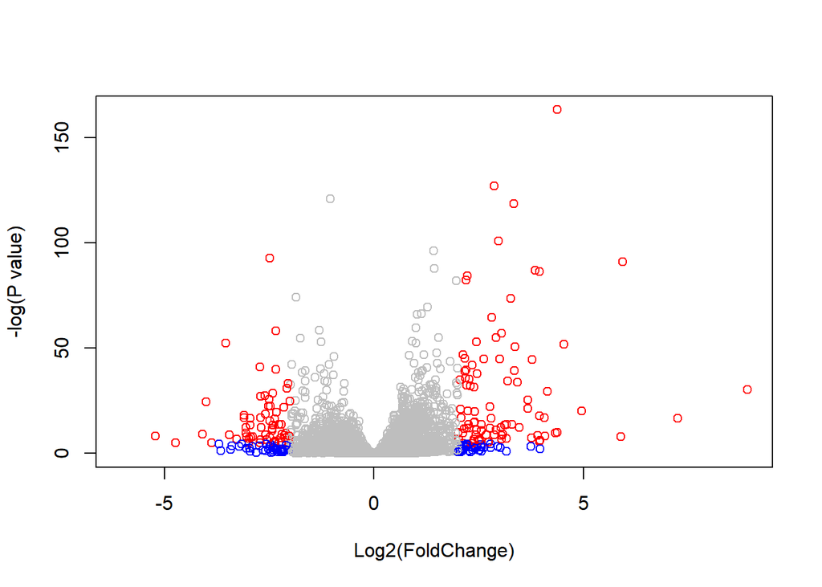

```r
# order gray < blue < red!

res01<-results(dds, alpha = 0.01)
mycols<- rep("gray", nrow(res01))
mycols[abs(res01$log2FoldChange)>2] <- "blue"

#p above p point threshold red
#change most of significant
mycols[ abs(res01$log2FoldChange) >2 & res01$padj < 0.01] <- "red"
plot(res01$log2FoldChange, -log(res01$padj), col=mycols, ylab="-log(P value)", xlab = "Log2(FoldChange)")
```

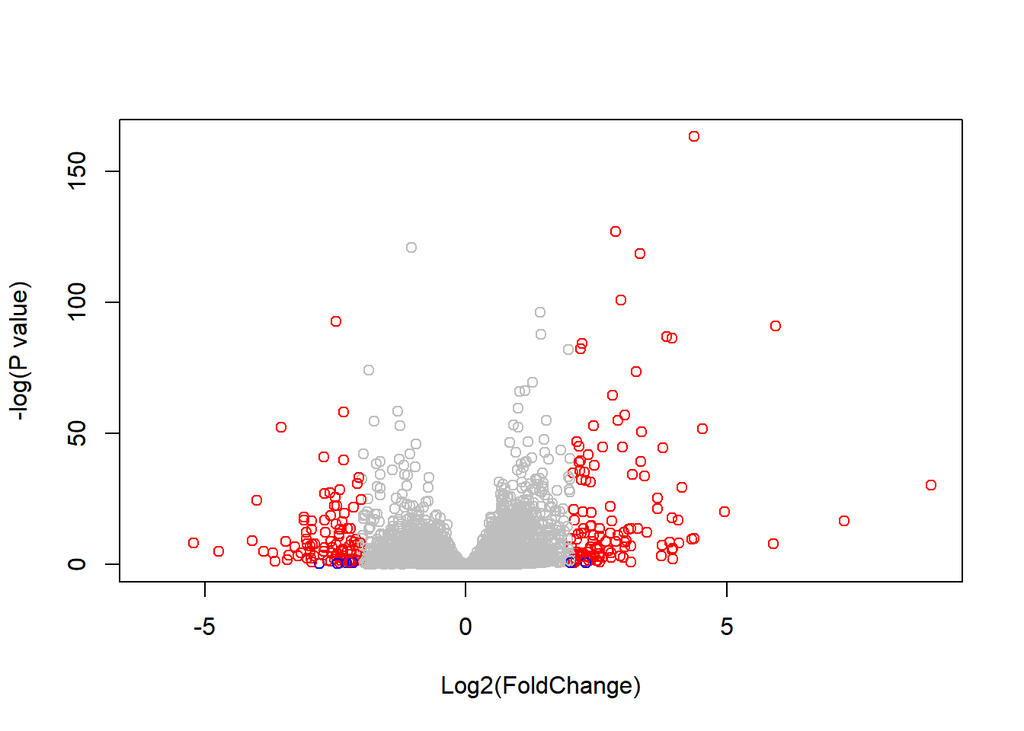

```r
#temp proj
volcanoPlot <- function(x) {

  resAny<-results(dds, alpha = x)
  mycols<- rep("gray", nrow(res01))
  mycols[abs(resAny$log2FoldChange)>2] <- "blue"

  #p above p point threshold red
  #change most of significant
  mycols[ abs(res01$log2FoldChange) >2 & resAny$padj < x] <- "red"
  plot(res01$log2FoldChange, -log(res01$padj), col=mycols, ylab="-log(P value)", xlab = "Log2(FoldChange)")
}
volcanoPlot(0.5)
```

#next up find the gene

tinyurl.com/class15-classmd